# Clicker Q

to go with **Introduction to Modern Statistics** by Çentinkaya-Rundel & Hardin. Math 58B - Introduction to Biostatistics.

1. If 16 infants with **no genuine preference** choose 16 toys, what is the most likely number of “helping” toys that will be chosen?[^1]
1. 4
2. 7
3. 8
4. 9
5. 10
2. How likely is it that exactly 8 helpers will be chosen (if there is no preference)?[^2]
1. 0-15%
2. 16-30%
3. 31-49%
4. 50%
5. 51-100%
3. What if we flipped a coin 160 times? What percent of the time will the simulation flip exactly 80 heads?[^3]
1. 0-15%
2. 16-30%
3. 31-49%
4. 50%
5. 51-100%
4. Is our actual result of 14 (under the coin model)…[^4]
1. very surprising?
2. somewhat surprising?
3. not very surprising?
5. Based on the first handwriting study, can we conclude that cursive causes higher scores (on average)?[^5]
   1. Yes
   2. No
   3. It depends
6. Based on the second handwriting study, can we conclude that cursive causes higher scores (on average)?[^6]
   1. Yes
   2. No
   3. It depends
7. A possible confounding variable for the handwriting study is:[^7]
1. grade of the student (age)
2. region of country where the SAT was taken
3. academic ability of the student
4. gender identity of the student
5. number of siblings of the student.
8. The main reason we randomly assign the explanatory variable is:[^8]
1. To get the smallest p-value possible
2. To balance the expected causal mechanism across the two groups
3. To balance every possible variable except the causal mechanism across the two groups
4. So that our sample is representative of the population
5. So that the sampling process is unbiased
9. The main reason we take random samples from the population is:[^9]
1. To get the smallest p-value possible
2. To balance the expected causal mechanism across the two groups
3. To balance every possible variable except the expected causal mechanism across the two groups
4. So that our sample is representative of the population
5. So that the sampling process is unbiased
10. Are there effects of second-hand smoke on the health of children?[^10]
    1. definitely obs study
    2. definitely experiment
    3. unhappily obs study
    4. unhappily experiment
11. Do people tend to spend more money in stores located next to food outlets with pleasing smells?[^11]
    1. definitely obs study
    2. definitely experiment
    3. unhappily obs study
    4. unhappily experiment
12. Does cell phone use increase the rate of automobile accidents?[^12]
    1. definitely obs study
    2. definitely experiment
    3. unhappily obs study
    4. unhappily experiment
13. Do people consume different amounts of ice cream depending on the size of bowl used?[^13]
    1. definitely obs study
    2. definitely experiment
    3. unhappily obs study
    4. unhappily experiment
14. Which is more effective: diet A or diet B?[^14]
    1. definitely obs study
    2. definitely experiment
    3. unhappily obs study
    4. unhappily experiment
15. Suppose that we record the midterm exam score and the final exam score for every student in a class. What would the value of the correlation coefficient be if every student in the class scored ten points higher on the final than on the midterm:[^15]
    1. r = -1
    2. -1 < r < 0
    3. r = 0
    4. 0 < r < 1
    5. r = 1
16. Suppose that we record the midterm exam score and the final exam score for every student in a class. What would the value of the correlation coefficient be if every student in the class scored five points lower on the final than on the midterm:[^16]
    1. r = -1
    2. -1 < r < 0
    3. r = 0
    4. 0 < r < 1
    5. r = 1
17. Suppose that we record the midterm exam score and the final exam score for every student in a class. What would the value of the correlation coefficient be if every student in the class scored twice as many points on the final than on the midterm:[^17]
    1. r = -1
    2. -1 < r < 0
    3. r = 0
    4. 0 < r < 1
    5. r = 1
18. Suppose you guessed every value correctly (guess the correlation applet), what would be the value of the correlation coefficient between your guesses and the actual correlations?[^18]
    1. r = -1
    2. -1 < r < 0
    3. r = 0
    4. 0 < r < 1
    5. r = 1
19. Suppose each of your guesses was too high by 0.2 from the actual value of the correlation coefficient, what would be the value of the correlation coefficient between your guesses and the actual correlations?[^19]
    1. r = -1
    2. -1 < r < 0
    3. r = 0
    4. 0 < r < 1
    5. r = 1
20. A correlation coefficient equal to 1 indicates that you are a good guesser.[^20]
    1. TRUE
    2. FALSE
21. Perfect Correlation… if not for a single outlier  
    n = 101 observations: 1 observation in top left, 25 observations in each in of the points near the bottom right.  
    The value of the correlation, r, is:[^21]
    1. -1 < r < -0.9
    2. -0.9 < r < -0.5
    3. -0.5 < r < 0.5
    4. 0.5 < r < 0.9
    5. 0.9 < r < 1

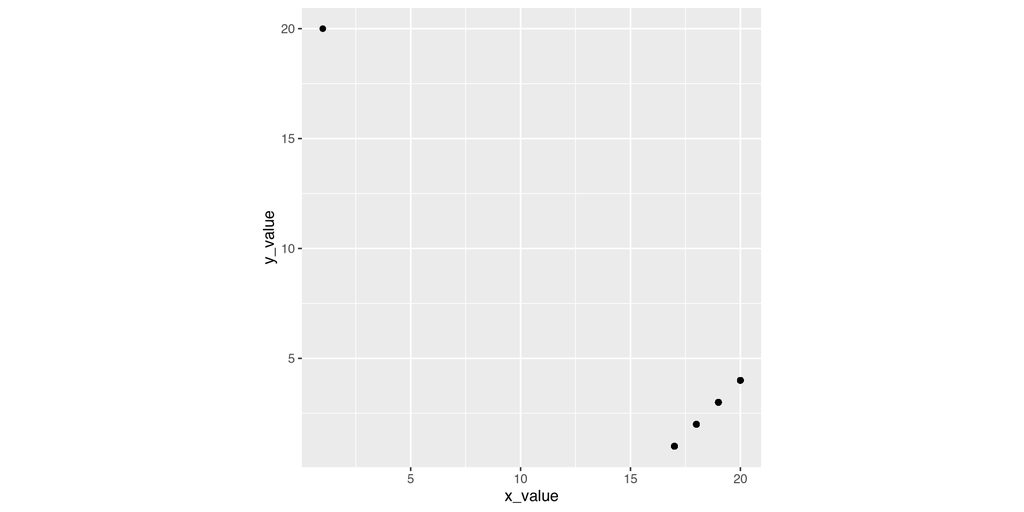

22. The sum of residuals from the sample mean (no X):[^22]
    $$\sum_{i=1}^n(Y_i - \overline{Y})$$
    1. is positive
    2. is negative
    3. is zero
    4. is different for every dataset
23. A good measure of how well the prediction (of the sample mean) fits the data is:[^23]
    1. $\sum_{i=1}^n(Y_i - \overline{Y})$
    2. $\sum_{i=1}^n(Y_i - \overline{Y})^2$
    3. $\sum_{i=1}^n|Y_i - \overline{Y}|$
    4. $\mbox{median}(Y_i - \overline{Y})$
    5. $\mbox{median}|Y_i - \overline{Y}|$
24. A good measure of how well the prediction (of the regression line) fits the data is:[^24]
    1. $\sum_{i=1}^n(Y_i - \hat{Y}_i)$
    2. $\sum_{i=1}^n(Y_i - \hat{Y}_i)^2$
    3. $\sum_{i=1}^n|Y_i - \hat{Y}_i|$
    4. $\mbox{median}(Y_i -\hat{Y}_i)$
    5. $\mbox{median}|Y_i -\hat{Y}_i|$
25. What math is used to find the value of $m$ that minimizes:[^25]
    $$\sum_{i=1}^n(Y_i - m)^2$$
    1. combinatorics
    2. derivative
    3. integral
    4. linear algebra
26. $\sum_i(Y_i - \overline{Y})^2$ is sometimes $\geq \sum_i(Y_i - \hat{Y}_i)^2$[^26]
    1. TRUE
    2. FALSE, $\sum_i(Y_i - \overline{Y})^2$ is always $\geq \sum_i(Y_i - \hat{Y}_i)^2$
    3. FALSE, $\sum_i(Y_i - \overline{Y})^2$ is never $\geq \sum_i(Y_i - \hat{Y}_i)^2$
27. When writing the regression equation, why is there a hat ( ^) on the response variable?[^27]
    1. because the prediction is an estimate
    2. because the prediction is an average
    3. because the prediction may be due to extrapolation
    4. a & b
    5. all of the above
28. “Observed data or more extreme” is:[^28]
    1. fewer than 9
    2. 9 or fewer
    3. 9 or more
    4. more than 9
29. What is the mean value of the null sampling distribution for the number of Botox therapy who showed pain reduction?[^29]
    1. 0
    2. 9
    3. 5.3
    4. 11
    5. 15
30. In the Botox and Pain Relief example, the p-value is calculated. What does “probability” refer to?[^30]
    1. random allocation
    2. random sample

p-value = probability of the observed data or more extreme given the null hypothesis is true.

31. What conclusion would you draw from the Back Pain and Botox study?[^31]
    1. Not enough evidence to conclude that Botox is more effective than the placebo.
    2. Strong evidence that Botox is equally as effective as the placebo.
    3. Strong evidence that Botox is more effective than the placebo.
32. If we consider those in the study with back pain to be representative of all people with back pain, what would you conclude about the percentage of people who will have reduced back pain if they use Botox?[^32]
    1. Substantially greater than 50%
    2. Substantially less than 50%
    3. Close to 50%
33. If communication medium and cheating are independent variables, how many of the email senders (out of 26) would you expect to cheat?[^33]
    1. 10 (ish)
    2. 13 (ish)
    3. 16 (ish)
    4. 20 (ish)
    5. 24 (ish)
34. When looking at the null differences, is the observed result of 28.7%:[^34]
    1. Very surprising
    2. Somewhat surprising
    3. Not very surprising
35. Hypothesis: the number of hours that grade-school children spend doing homework predicts their future success on standardized tests.[^35]
    1. null, one sided
    2. null, two sided
    3. alternative, one sided
    4. alternative, two sided
36. Hypothesis: king cheetahs on average run the same speed as standard spotted cheetahs.[^36]
    1. null, one sided
    2. null, two sided
    3. alternative, one sided
    4. alternative, two sided
37. Hypothesis: the mean length of African elephant tusks has changed over the last 100 years.[^37]
    1. null, one sided
    2. null, two sided
    3. alternative, one sided
    4. alternative, two sided
38. Hypothesis: the risk of facial clefts is equal for babies born to mothers who take folic acid supplements compared with those from mothers who do not.[^38]
    1. null, one sided
    2. null, two sided
    3. alternative, one sided
    4. alternative, two sided
39. Hypothesis: caffeine intake during pregnancy affects mean birth weight.[^39]
    1. null, one sided
    2. null, two sided
    3. alternative, one sided
    4. alternative, two sided
40. Material check-in
    1. So far, so good
    2. Concepts are good, R is confusing
    3. R is good, concepts are confusing
    4. Everything is confusing
41. People check-in
    1. So far, so good
    2. I can go to office hours / mentor sessions, but I didn’t go this week.
    3. I can’t make the scheduled office hours / mentor sessions
    4. I’m looking for someone to study with

See Canvas front page for **anonymous** survey / feedback for the class. Also, if you are looking for people to work with, you could contact me directly (non-anonymously!) so that I can connect you to people.

42. I know where to find: the solutions to the worksheets, the clicker questions (with solutions), and the HW/Lab solutions[^40]
    1. TRUE
    2. FALSE
43. You have a sample of size n = 50. You sample with replacement 1000 times (to get 1000 bootstrap resamples). What is the sample size of each bootstrap resample?[^41]
    1. 50
    2. 1000
44. You have a sample of size n = 50. You sample with replacement 1000 times (to get 1000 bootstrap resamples). How many bootstrap statistics will you have?[^42]
    1. 50
    2. 1000
45. In this class, the word parameter means:[^43]
    1. The values in a model
    2. Numbers that need to be tuned
    3. A number which is calculated from a sample of data.
    4. A number which (is almost always unknown and) describes a population.
46. First study: Let’s say you take a random sample and compute $\hat{p}=0.3.$ After bootstrapping, you see that 95% of the bootstrapped resamples ($\hat{p}_{boot}$) are within plus or minus 0.01 of your original statistic ($\hat{p}$). It seems that the parameter $p$ is probably:[^44]
    1. 0.3
    2. between (0.2, 0.4)
    3. between (0.29, 0.31)
    4. between (0.28, 0.32)
    5. huh? how can we get $p$ from $\hat{p}?$
47. In a second analysis, I create a 90% CI for the true proportion $p.$ What is the impact (of switching from 95% to 90%) on the CI?[^45]
    1. narrower
    2. less likely (long-run) to capture the parameter
    3. neither
    4. both
48. In a third study, I set out to obtain twice as much data (as in the first study) in order to create a 95% CI for the true proportion $p.$ What is the impact (of the larger sample) on the CI?[^46]
    1. narrower
    2. more likely (long-run) to capture the parameter
    3. neither
    4. both
49. What is one main reason to use bootstrapping to find a confidence interval?[^47]
    1. larger coverage probabilities
    2. narrower intervals
    3. more resistant to outliers
    4. can be done for any statistic
50. 95% CI for the true median mercury:[^48]
    1. (0.025 mg/kg, 0.975 mg/kg)
    2. (0.469 mg/kg, 0.053 mg/kg)
    3. (0.053 mg/kg, 0.469 mg/kg)
    4. (0.34 mg/kg, 0.56 mg/kg)

[figure not shown]

From StatKey applet: https://www.lock5stat.com/StatKey/

51. What are the observational units for your individual candy study?[^49]
    1. Color of the candy
    2. Piece of candy
    3. Cup of candy
    4. The Hershey Company
    5. Proportion that are orange
52. What are the observational units for the class compilation (dotplot)?[^50]
    1. Color of the candy
    2. Piece of candy
    3. Cup of candy
    4. The Hershey Company
    5. Proportion that are orange
53. How does the sampling distribution for the sample proportion change as n changes (for a fixed p)?[^51]
    1. The spread changes
    2. The symmetry changes
    3. The center changes
    4. The shape changes
54. How does the sampling distribution change as p changes (for a fixed n)?[^52]
    1. The spread changes
    2. The symmetry changes
    3. The center changes
    4. The shape changes
55. The Central Limit Theorem says that the distribution of $\hat{p}$ will be approximately normal with what center:[^53]
    1. $\hat{p}$
    2. $p$
    3. 0.5
    4. 1
    5. $\sqrt{p(1-p) / n}$
56. Would you rather have an extra 20 points on the SAT or an extra 10 points on the ACT?[^54]
    1. +20 on the SAT
    2. +10 on the ACT
57. The standardized score (z-score) counts:[^55]
    1. the number of standard deviations from the mean
    2. the number of standard deviations above the mean
    3. the number of standard deviations below the mean
    4. the distance from the mean
    5. the distance from the standard deviation
58. If the normal distribution is a good model, we would expect the large majority of our z scores to be:[^56]
    1. within $\pm$ 1 of the mean
    2. within $\pm$ 2 of the mean
    3. within $\pm$ 1
    4. within $\pm$ 2
59. With your cup of candy, you personally got a Z score of:[^57]
    1. between (-1, 1) (not including 1)
    2. between (-2, -1] or [1, 2)
    3. between (-3, -2] or [2, 3)
    4. -3 or smaller or 3 or above
60. Assume n = 100 and p= 0.8 (note: $\sqrt{(0.8 \cdot 0.2)/100} = 0.4/10 = 0.04$)  
    What is the largest reasonable distance between $\hat{p}$ and $p$?  
    That is, we would expect $\hat{p}$ and $p$ to be no more than _____ apart[^58]
    1. 0.04
    2. 0.08
    3. 0.12
    4. 0.16
    5. 0.24
61. Assume n = 100 and p= 0.8 (note: $\sqrt{(0.8 \cdot 0.2)/100} = 0.4/10 = 0.04$) Which statement is true?[^59]
    1. 95% of $\hat{p}$ are between (0.76, 0.84)
    2. 95% of $\hat{p}$ are between (0.72, 0.88)
    3. 95% of $\hat{p}$ are between (0.68, 0.92)
    4. 95% of $p$ are between (0.76, 0.84)
    5. 95% of $p$ are between (0.72, 0.88)
62. If you want a 90% confidence interval for p, your z* multiplier should be[^60]
    1. less than 1
    2. less than 2 (but greater than 1)
    3. equal to 2
    4. greater than 2 (but less than 3)
    5. greater than 3
63. What is the difference between Z* and a Z score?[^61]
    1. Z score comes from the data, Z* and is a pre-defined unit of measurement.
    2. Z* comes from the data, and Z score is a pre-defined unit of measurement
    3. Z score assumes the null hypothesis is true and Z* doesn’t.
    4. Z* assumes the null hypothesis is true, and Z score doesn’t
64. Let’s say we are making confidence intervals (not doing a hypothesis test), what is your best guess for $SE(\hat{p})$?[^62]
    1. $\sqrt{0.5 \cdot (1 - 0.5) / n}$
    2. $\sqrt{p \cdot (1 - p) / n}$
    3. $\sqrt{\hat{p} \cdot (1 - \hat{p}) / n}$
    4. $\sqrt{X \cdot (1 - X) / n}$
    5. $\sqrt{0.95 \cdot (1 - 0.95) / n}$
65. The following is a correct interpretation of the CI:[^63]

> 95% confident that the interval includes the sample proportion who believe that the global poverty rate has doubled.
1. TRUE
2. FALSE
66. The following is a correct interpretation of the CI:[^64]

> If researchers were to select a new sample of 1005 adult Americans, then we’re 95% confident that between 56% and 62% of those people would answer “doubled” to the question.
1. TRUE
2. FALSE
67. Let’s say that the null hypothesis (e.g., p=0.47) is TRUE. I reject $H_0$ if the p-value < 0.03. How often will I reject the null hypothesis?[^65]
    1. 1 % of the time
    2. 3% of the time
    3. 5 % of the time
    4. 95% of the time
    5. 97% of the time

What does “of the time” mean???

It means in repeated samples. That is, in 3% of all datasets we’d take from that exact same population, we would mistakenly reject the actually true hypothesis that p=0.47.

68. Let’s say that the null hypothesis (e.g., p=0.47) is TRUE. I reject $H_0$ if the p-value < 0.03. How often will p be in a 97% confidence interval?[^66]
    1. 1 % of the time
    2. 3% of the time
    3. 5 % of the time
    4. 95% of the time
    5. 97% of the time

What does “of the time” mean???

It means in repeated samples. That is, in 97% of all datasets we’d take from that exact same population, we would capture the true population proportion of 0.47.

69. Suppose the sample is 10 times larger. The SE of the statistic:[^67]
    1. increases
    2. stays the same
    3. decrease
70. Suppose the population is 10 times larger. The SE of the statistic:[^68]
    1. increases
    2. stays the same
    3. decrease
71. Suppose the sample is 10 times larger. The variability of the data:[^69]
    1. increases
    2. stays the same
    3. decrease
72. How many hits out of 20 at bats would make you believe him?[^70]
    1. 5
    2. 6
    3. 7
    4. 8
    5. 9
73. Type I error is[^71]
    1. We give him a raise when he deserves it.
    2. We don’t give him a raise when he deserves it.
    3. We give him a raise when he doesn’t deserve it.
    4. We don’t give him a raise when he doesn’t deserve it.
74. Type II error is[^72]
    1. We give him a raise when he deserves it.
    2. We don’t give him a raise when he deserves it.
    3. We give him a raise when he doesn’t deserve it.
    4. We don’t give him a raise when he doesn’t deserve it.
75. Power is the probability that:[^73]
    1. We give him a raise when he deserves it.
    2. We don’t give him a raise when he deserves it.
    3. We give him a raise when he doesn’t deserve it.
    4. We don’t give him a raise when he doesn’t deserve it.
76. The player is more worried about[^74]
    1. A type I error
    2. A type II error
77. The manager is more worried about[^75]
    1. A type I error
    2. A type II error
78. Increasing your sample size[^76]
    1. Increases your power
    2. Decreases your power
79. Making your discernibility level more stringent ($\alpha$ smaller)[^77]
    1. Increases your power
    2. Decreases your power
80. A more extreme alternative[^78]:
    1. Increases your power
    2. Decreases your power
81. Alien example (see notes 4.6.1): Is the Alien’s interval for the true proportion of all humans who self-identify as female consistent with your lived experience?[^79]
    1. Yes
    2. No
    3. I don’t understand what the confidence interval represents.
82. Alien example (see notes 4.6.1): As we’ve seen with the applet, about 5% of all 95% intervals fail to capture the actual value of the population parameter. Do you think the alien just got a “red” interval?[^80]
    1. Yes
    2. No
83. Alien example (see notes 4.6.1): Would it be reasonable for the alien to conclude, with 95% confidence, that between 17.4% and 34.6% of US Senators in the year 2026 self-identify as female?[^81]
    1. Yes
    2. No
84. Gettysburg example (see notes 4.6.2): As we’ve seen with the applet, about 5% of all 95% intervals fail to capture the actual value of the population parameter. Do you think you just got a “red” interval for proportion of short words?[^82]
    1. Yes
    2. No
85. The “random” part in clinical trials typically comes from:[^83]
    1. random samples
    2. random allocation of treatment
86. The “random” part in polling typically comes from:[^84]
    1. random samples
    2. random allocation of treatment
87. You want to collect data to investigate whether teenagers in the United States have read fewer Harry Potter books than teenagers in the United Kingdom. Would you make use of random sampling, random assignment, both, or neither?[^85]
    1. Random sampling
    2. Random assignment
    3. Both
    4. Neither
88. An instructor wants to investigate whether using a red pen to grade assignments leads to lower scores on exams than using a blue pen to grade assignments. Would you advise the professor to make use of random sampling, random assignment, both, or neither?[^86]
    1. Random sampling
    2. Random assignment
    3. Both
    4. Neither
89. A student decides to investigate whether NFL football games played in indoor stadiums tend to have more points scored than games played outdoors. The student examines points scored in every NFL game of the 2022 season. Has the student used random sampling, random assignment, both, or neither?[^87]
    1. Random sampling
    2. Random assignment
    3. Both
    4. Neither
90. Relative Risk is[^88]
    1. the difference of two proportions
    2. the ratio of two proportions
    3. the log of the ratio of two proportions
    4. the log of the difference of two proportions
91. In order to find a CI for the true RR, our steps are:[^89]  
    Step 1. ln(RR-hat)  
    Step 2. add ± z* sqrt( 1/A - 1/(A+C) + 1/B - 1/(B+D) )  
    Step 3. find exp of the endpoints
    1. because the sampling distribution of RR is normal
    2. because RR is typically greater than 1
    3. because the ln transformation makes the sampling distribution almost normal
    4. because RR is invariant to the choice of explanatory or response variable
92. In finding a CI for $p_1$/$p_2$, why is it okay to exponentiate the end points of the interval for ln($p_1$/$p_2$)?[^90]
    1. if ln($p_1$/$p_2$) is in the natural log-interval, $p_1$/$p_2$ will be in the exponentiated interval.
    2. the natural log of the RR makes the distribution approximately normal.
    3. the natural log compresses values that are > 1 and spreads values < 1.
93. Usually, the CI for $p_1$/$p_2$ is considered to be “discernible” if[^91]
    1. $p_1$/$p_2$ is not in the interval
    2. $\hat{p}_1 / \hat{p}_2$ is not in the interval
    3. 0 is not in the interval
    4. 1 is not in the interval
94. In order to find a CI for the true OR, our steps are:[^92]  
    Step 1. ln(OR-hat)  
    Step 2. add ± z* sqrt( 1/A + 1/B + 1/C + 1/D )  
    Step 3. find exp of the endpoints
    1. because the sampling distribution of OR is normal
    2. because OR is typically greater than 1
    3. because the ln transformation makes the sampling distribution almost normal
    4. because OR is invariant to the choice of explanatory or response variable
95. Sample 1,000,000 people who are over 6’ tall and 1,000,000 people who are under 6’ tall. Record if the person is in the NBA.  
    What is measurable?[^93]
    1. P(NBA if 6’ tall)
    2. P(6’ tall if in the NBA)
    3. both
    4. neither
96. Sample 100 people who are in the NBA and 100 people who are not in the NBA. Record if the person is over 6’ tall. What is measurable?[^94]
    1. P(NBA if 6’ tall)
    2. P(6’ tall if in the NBA)
    3. both
    4. neither
97. Sample 10,000,000 people. Record their height and whether or not they are in the NBA.  
    What is measurable?[^95]
    1. P(NBA if 6’ tall)
    2. P(6’ tall if in the NBA)
    3. both
    4. neither

From the NYT, March 21, 2023, https://www.nytimes.com/2023/03/21/sports/basketball/tall-basketball-march-madness.html

> The average W.N.B.A. player, at a shade taller than 6 feet, towers over the average American woman (5 feet 3.5 inches). American men who are between 6 feet and 6-2 — significantly taller than the 5-9 average — have about a five in a million chance of making the N.B.A., according to “The Sports Gene,” a 2013 book by David Epstein about the science of athletic performance. But if you hit the genetic lottery and happen to be 7 feet tall, your chances of landing in the N.B.A. are roughly one in six. (There are 38 players on active rosters who are 7 feet or taller, according to N.B.A. Advanced Stats; the average height of an N.B.A. player is 6 feet 6.5 inches.)

https://davidepstein.com/david-epstein-the-sports-gene/

98. When we randomly select individuals based on the explanatory variable, we cannot accurately measure[^96]
    1. the proportion of people in the population in each explanatory category
    2. the proportion of people in the population in each response group
    3. anything about the population
    4. confounding variables
99. The odds ratio is invariant to which variable is explanatory and which is response means:[^97]
    1. we always put the bigger odds in the numerator
    2. we must collect data so that we can estimate the response in the population
    3. which variable is called the explanatory changes the value of the OR
    4. which variable is called the explanatory does not change the value of the OR
100. One reason we should be careful interpreting relative risks is if:[^98]
     1. we don’t know the difference in proportions
     2. we don’t know the SE of the relative risk
     3. we might be dividing by zero
     4. we don’t know the baseline risk
101. If the null hypothesis is true, the observed counts will equal the expected counts.[^99]
     1. True
     2. False
102. To reject the null hypothesis we want to see[^100]
     1. a small $X^2$ value
     2. a big $X^2$ value
103. A chi-square test has a[^101]
     1. one-sided alt hypothesis, and we only consider the upper end of the sampling distribution
     2. one-sided alt hypothesis, and we consider both ends of the sampling distribution
     3. two-sided alt hypothesis, and we only consider the upper end of the sampling distribution
     4. two-sided alt hypothesis, and we consider both ends of the sampling distribution
104. For the lighting study, which variable is the explanatory variable?[^102]
     1. sleeping light
     2. eye sightedness
     3. child
     4. parent
105. If we sample randomly from a population, the conclusions we can make are about:[^103]
     1. causation
     2. population characteristics
106. Based on the night light / myopia example, the correct conclusion is:[^104]
     1. the p-value is small, so sleeping in a lit room makes it more likely that you are near-sighted.
     2. the p-value is small, so sleeping in a dark room makes it more likely that you are near-sighted.
     3. the p-value is small, so a higher proportion of children who sleep in light rooms are near-sighted than who sleep in dark rooms.
     4. $\hat{p}_{\mbox{near}}$ if lit room = 41/75 = 0.547 and $\hat{p}_{\mbox{near}}$ if dark = 18/172 = 0.105, therefore sleeping with the light on is bad for you.
107. A possible confounding variable for the night light study is:[^105]
     1. low birth weight
     2. race (70% of the children were white)
     3. region of the country where the clinic was located
108. Which dataset has the smallest standard deviation?[^106]
     1. A: left
     2. B: center
     3. C: right

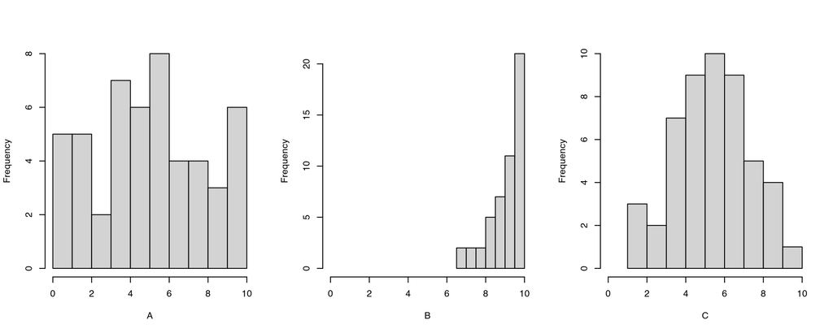

109. Which of the two dotplots displays the dataset with the smaller IQR?[^107]
     1. A
     2. B

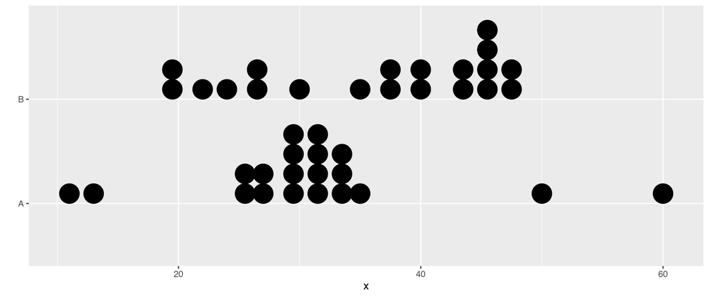

110. The standard deviation of weights (mean = 167 lbs) is approximately[^108]
     1. 1
     2. 5
     3. 10
     4. 35
     5. 100
111. The standard deviation of average weights (mean = 167 lbs) in repeated samples of size 10 is approximately[^109]
     1. 1
     2. 5
     3. 10
     4. 35
     5. 100
112. The standard deviation of average weights (mean = 167 lbs) in repeated samples of size 50 is approximately[^110]
     1. 1
     2. 5
     3. 10
     4. 35
     5. 100
113. The standard deviation of average weights (mean = 167 lbs) in repeated samples of size 1000 is approximately[^111]
     1. 1
     2. 5
     3. 10
     4. 35
     5. 100

Q: what is the most confusing part of understanding the difference between the variability of the weights and the variability of the average of the weights?

114. The sampling distribution of the mean will be[^112]
     1. centered below the data distribution
     2. centered at the same place as the data distribution
     3. centered above the data distribution
     4. unrelated to the center of the data distribution
115. The sampling distribution of the mean will be[^113]
     1. less variable than the data distribution
     2. the same variability as the data distribution
     3. more variable than the data distribution
     4. unrelated to the variability of the data distribution
116. Why did we switch from talking about total weight to talking about average weight?[^114]
     1. So that it is easier to infer from the sample to the population.
     2. Because the Coast Guard certifies vessels according to average weight.
     3. Because the average is less variable than the sum.
     4. Because the average has a normal distribution and the sum doesn’t.
117. When the population is skewed right, the sampling distribution for the sample mean will be[^115]
     1. always skewed right
     2. skewed right if n is big enough
     3. always normal
     4. normal if n is big enough
118. What does the CLT say?[^116]
119. What type of variable is “healthy body temp”?[^117]
     1. explanatory
     2. response
120. We use $s$ instead of $\sigma$ because[^118]
     1. we know $s$ and we don’t know $\sigma$
     2. $s$ is a better estimate of the st dev
     3. $s$ is less variable than $\sigma$
     4. we want our test statistic to vary as much as possible
     5. we like the letter t better than the letter z
121. The variability associated with $\overline{X}$ is[^119]
     1. less than the variability of X
     2. more than the variability of X
     3. the same as the variability of X
     4. unrelated to the variability of X
     5. some other function of X
122. If asked to “determine how many standard errors the sample mean (98.249) falls from the hypothesized value of 98.6”, which formula should you use?[^120]
     1. $\frac{(98.249-98.6)}{s}$
     2. $\frac{(98.249-98.6)}{s/\sqrt{n}}$
     3. $\frac{(98.249-98.6)}{\sigma}$
     4. $\frac{(98.249-98.6)}{\sigma/\sqrt{n}}$
123. When we use $s$ instead of $\sigma$ in the CI for $\mu$, but still keep z* (instead of using a t* multiplier), the resulting CI has coverage[^121]
     1. **LESS** than the stated confidence level
     2. **MORE** than the stated confidence level
     3. **OF** the stated confidence level
124. What is the difference between t* and a t score?[^122]
     1. t score comes from the data, t* and is a pre-defined unit of measurement.
     2. t* comes from the data, and t score is a pre-defined unit of measurement
     3. t score assumes the null hypothesis is true and t* doesn’t.
     4. t* assumes the null hypothesis is true, and t score doesn’t
125. What is the correct interpretation of the 92% CI for $\mu$ which is given as (98.2, 98.3)?[^123]
     1. 92% of intervals will be (98.2, 98.3).
     2. 92% of individual temperatures will be between (98.2, 98.3).
     3. There is a 0.92 probability that the true temperature is between (98.2, 98.3).
     4. There is a 0.92 probability that the true average temperature is between (98.2, 98.3).
     5. In repeated samples, 92% of the intervals will contain $\mu.$
126. Let’s say you *truly* believe that the true average body temp is between (98.2, 98.3). (Your CI is green.) You record a temp of 98.6 F. Do you think you are sick?[^124]
     1. Yes, it is outside the range above.
     2. No, I still believe $\mu$ is 98.6.
     3. No, 98.6 isn’t too far above the upper bound.
     4. No, the interval isn’t for individual people.
127. The variability associated with $\overline{X}$ is[^125]
     1. less than the variability of X
     2. more than the variability of X
     3. the same as the variability of X
     4. unrelated to the variability of X
     5. some other function of X
128. The variability associated with predicting a new value, $X_{n+1}$,[^126]
     1. is less than the variability of $\overline{X}$
     2. is more than the variability of $\overline{X}$
     3. is the same as variability of $\overline{X}$
     4. is less than the variability of X
     5. is more than the variability of X
129. Prediction intervals are[^127]
     1. smaller than confidence intervals
     2. about the same width as confidence intervals
     3. larger than confidence intervals
     4. unrelated to confidence intervals
130. Where should a prediction interval for a new value, $X_{n+1}$, be centered?[^128]
     1. $\overline{X}$
     2. $\mu$
     3. 98.6
     4. $X_1$ (the first person in the dataset)
     5. $X_n$ (the last person in the dataset)
131. What is the correct interpretation of the 95% PI for $X_{n+1}$ which is given as (96.79, 99.70)?[^129]
     1. 95% of intervals will be (96.79, 99.70).
     2. 95% of individual temperatures will be between (96.79, 99.70).
     3. There is a 0.95 probability that the true temperature is between (96.79, 99.70).
     4. There is a 0.95 probability that the true average temperature is between (96.79, 99.70).
     5. In repeated samples, 95% of the intervals will contain $\mu.$
132. Prediction intervals have[^130]
     1. the same technical conditions as CIs
     2. stricter technical conditions than CIs
     3. more lenient technical conditions than CIs
     4. technical conditions which are unrelated to CIs
133. When the population is skewed right, the sampling distribution for the sample mean will be[^131]
     1. always skewed right
     2. skewed right if n is big enough
     3. always normal
     4. normal if n is big enough
134. When the population is skewed right, the distribution for the data will be[^132]
     1. always skewed right
     2. skewed right if $n$ is big enough
     3. always normal
     4. normal if $n$ is big enough
135. A newspaper article claims that the average age for people who receive food stamps is 40 years. You believe that the average age is lower. You take a random sample of 100 people who receive food stamps and find their average age to be 39.2 years. You find that 39.2 is discernibly lower than the age of 40 stated in the article (p < 0.05). What would be an appropriate interpretation of the result?[^133]
     1. The statistically discernible result indicates that the majority of people who receive food stamps is younger than 40.
     2. Although the result is statistically discernible, the difference in age is not of practical importance.
     3. An error must have been made. This difference is too small to be statistically discernible.
136. In order to investigate a claim that the average time required for the county fire department to respond to a reported fire is greater than 5 minutes, county staff determined the response times for 40 randomly selected fire reports. The data were used to test $H_0: \mu = 5$ versus $H_a: \mu > 5$, and the computed p-value was 0.12. If a 0.05 level of discernibility is used, what conclusions can be drawn?[^134]
     1. There is convincing evidence that the mean response time is 5 minutes (or less).
     2. There is convincing evidence that the mean response time is greater than 5 minutes.
     3. There is not convincing evidence that the mean response time is greater than 5 minutes.
137. You have two samples of size n = 50. You sample with replacement 1000 times (to get 1000 bootstrap resamples). What is the sample size of each bootstrap resample?[^135]
     1. 50
     2. 1000
138. You have two samples of size n = 50. You sample with replacement 1000 times (to get 1000 bootstrap resamples). How many bootstrap statistics will you have?[^136]
     1. 50
     2. 1000
139. You have two samples of size n = 50. You shuffle the explanatory and response variables (i.e., sample without replacement) 1000 times. What is the sample size of each group after shuffling?[^137]
     1. 50
     2. 1000
140. You have two samples of size n = 50. You shuffle the explanatory and response variables (i.e., sample without replacement) 1000 times. How many randomization statistics will you have?[^138]
     1. 50
     2. 1000
141. We typically compare means instead of medians because[^139]
     1. we don’t know the SE of the difference of medians
     2. means are inherently more interesting than medians
     3. the randomization applet (or R code) doesn’t work with medians
     4. the Central Limit Theorem doesn’t apply for medians
142. $SE(\overline{X}_1 - \overline{X}_2)$ is:[^140]
     1. $\sqrt{\frac{\sigma_1^2}{n_1} + \frac{\sigma_2^2}{n_2}}$
     2. $\sqrt{\frac{\sigma_1^2}{n_1} - \frac{\sigma_2^2}{n_2}}$
     3. $\sqrt{\frac{s_1^2}{n_1} + \frac{s_2^2}{n_2}}$
     4. $\sqrt{\frac{s_1^2}{n_1} - \frac{s_2^2}{n_2}}$
     5. $\sqrt{s_1^2 - s_2^2}$
143. The distribution of age of death is:[^141]
     1. right skewed
     2. left skewed
     3. symmetric
     4. can’t tell with this information
144. The standard deviation for the age of death is likely around:[^142]
     1. 1 year
     2. 10 years
     3. 20 years
     4. 50 years
     5. 100 years
145. The number of left handed people is likely:[^143]
     1. 10
     2. 100
     3. 300
     4. 500
     5. 900
146. Are the two samples (lefties and righties) independent?[^144]
     1. yes
     2. no
     3. we can’t tell
147. For the handedness example, which has a lower p-value?[^145]
     1. Scenario 2
     2. Scenario 3
148. For the handedness example, which has a lower p-value?[^146]
     1. Scenario 3
     2. Scenario 4
149. How does each affect the power?[^147]
1. increasing the sample sizes of both groups
   1. increases the power
   2. doesn’t change the power
   3. decreases the power
2. larger variability within the groups
   1. increases the power
   2. doesn’t change the power
   3. decreases the power
3. larger difference in actual (population) group means
   1. increases the power
   2. doesn’t change the power
   3. decreases the power
150. We use the t-distribution (instead of the z-distribution) because:[^148]
     1. the CLT makes the test statistic normal
     2. the CLT makes the numerator of the test statistic normal
     3. the variability in the denominator makes the test statistic more variable
     4. the variability in the denominator makes the test statistic less variable
151. If we use the SE and the z-curve (instead of t-curve) to find the p-value (assuming $\overline{X}$ values are reasonably different):[^149]
     1. the p-value will be too small
     2. the p-value will be too big
     3. the p-value will be just right
     4. the p-value is unrelated to the curve
     5. we should use the SD instead
152. If we use the SE and the z-curve (instead of t-curve) to find a 95% CI:[^150]
     1. The capture rate will be at 95% over the long run.
     2. The capture rate will be higher than 95% over the long run.
     3. The capture rate will be lower than 95% over the long run.
153. What is the primary reason to use a matched pairs design?[^151]
     1. To increase the sample size
     2. To ensure that not everyone is assigned to the treatment group.
     3. To reduce the variability
     4. To find a better estimate of $\mu_1 - \mu_2$
154. A farmer wants to see whether referring to cows by name increases their milk production. He selects half of his cows at random, gives them names, and frequently calls them by name. The other half of his cows he does not call by name. Then he measures the milk production of each cow over a one-week period.[^152]
     1. paired
     2. independent
155. A farmer wants to know whether hand-milking or machine-milking tends to produce more milk from cows. He examines records of how much milk the cows have produced in the past, and orders them from most to least productive. For the top two milk producers, randomly assign one to hand-milking and the other to machine-milking. Do the same for the next two and the next two and so on.[^153]
     1. paired
     2. independent
156. You wonder whether students at your school tend to drive newer cars than faculty at your school. You take a random sample of 20 students and a random sample of 10 faculty members, and ask each person how old their car is.[^154]
     1. paired
     2. independent
157. In the ANOVA setting, the null hypothesis is always:
     $$H_0: \mu_1 = \mu_2 = \mu_3 = \ldots = \mu_I$$
     What is the alternative hypothesis?[^155]
     1. $H_a: \mu_1 \ne \mu_2 \ne \mu_3 \ne \ldots \ne \mu_I$
     2. $H_a: \mu_1 = \mu_2 = \mu_3 = \ldots = \mu_I = \mu$ (for some $\mu$ value)
     3. $H_a$: at least one $\mu_i$ is different
     4. $H_a$: at least one $\mu_i$ is discernibly different
     5. $H_a$: at least one $\mu_i$ is a lot different
158. In order to tell whether the differences in sample means are discernible, we need to ALSO know:[^156]
     1. how variable the observations are
     2. the distribution of the observations
     3. the sample sizes
     4. all of the above
     5. some of the above
159. Which is more discernible?[^157]
     1. A
     2. B
     3. They are the same
     4. We can’t tell

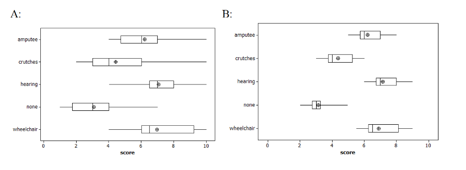

160. We reject the null hypothesis if:[^158]
     1. the between group variability is much bigger than the within group variability
     2. the within group variability is much bigger than the between group variability
     3. the within group variability and the between group variability are both quite large
     4. the within group variability and the between group variability are both quite small
161. What types of values will the F-ratio have when the null hypothesis is false, that is, when the population means are not all equal?[^159]
     1. large, positive
     2. large, negative
     3. small, positive
     4. small, negative
162. With ANOVA, if the null hypothesis is true, then[^160]
     $$H_0: \overline{X}_1 = \overline{X}_2 = \overline{X}_3 = \ldots = \overline{X}_I$$
     1. TRUE
     2. FALSE
163. How can I figure out which $\mu_i$ is different?[^161]
     1. The ANOVA reports it
     2. Do repeated one sample mean tests, but worry about type I errors
     3. Do repeated one sample mean tests, but worry about type II errors
     4. Do repeated two sample mean tests, but worry about type I errors
     5. Do repeated two sample mean tests, but worry about type II errors
164. Consider a categorical variable with 4 levels. In addition to the intercept how many variables show up in the linear model output?[^162]
     1. 1
     2. 3
     3. 4
     4. n-4
     5. n
165. If there is no relationship in the population (true correlation $\rho = 0$), then $r=0.$[^163]
     1. TRUE
     2. FALSE
166. If there is no relationship in the population (true slope $\beta_1 = 0$), then $b_1=0.$[^164]
     1. TRUE
     2. FALSE
167. If we set a parameter equal to XXXX, should we expect the statistic to be XXXX?[^165]
     1. Yes
     2. No
168. A smaller variability around the regression line (can be thought of as: $\sigma$ or MSE or variability of the $e_i$):[^166]
     1. increases the variability of $b_1.$
     2. decreases the variability of $b_1.$
     3. doesn’t necessarily change the variability of $b_1.$
169. A smaller variability in the explanatory variable (SD(X) = $s_x$):[^167]
     1. increases the variability of $b_1.$
     2. decreases the variability of $b_1.$
     3. doesn’t necessarily change the variability of $b_1.$
170. A smaller sample size ($n$):[^168]
     1. increases the variability of $b_1.$
     2. decreases the variability of $b_1.$
     3. doesn’t necessarily change the variability of $b_1.$
171. The regression technical assumptions include:[^169]
     1. The Y variable is normally distributed
     2. The X variable is normally distributed
     3. The residuals are normally distributed
     4. The slope coefficient is normally distributed
     5. The intercept coefficient is normally distributed
172. The technical conditions do not include:[^170]
     1. normally distributed residuals
     2. normally distributed response at each X
     3. normally distributed explanatory variable
     4. constant variance
     5. independence of observations
173. What happens if the technical conditions are not met?[^171]
     1. The line does not minimize the sum of squared residuals.
     2. $R^2$ does not measure the proportion of variability explained by the line.
     3. The null sampling distribution of $b_1$ is wrong (therefore incorrect p-values and CI).
     4. The computer (R) will produce an error when running the linear model.
174. Which linear regression condition is violated?[^172]
     1. linearity
     2. equal variance of errors
     3. independent errors
     4. normal errors
     5. outliers

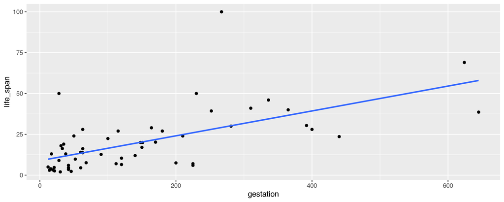

175. Which linear regression condition is violated?[^173]
     1. linearity
     2. constant errors
     3. independent errors
     4. normal errors
     5. outliers

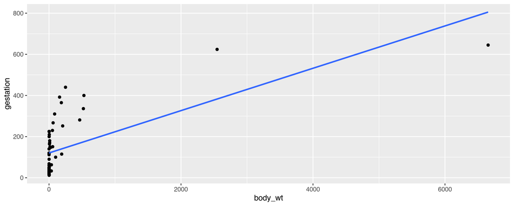

176. Which linear regression condition is violated?[^174]
     1. linearity
     2. constant errors
     3. independent errors
     4. normal errors
     5. outliers

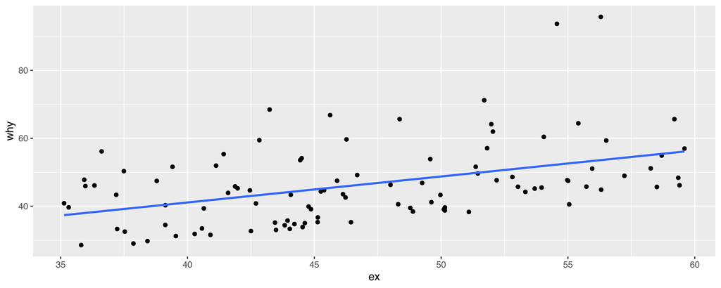

177. It is often a good idea to transform the variable(s)…[^175]
     1. … to find the highest $R^2$ value.
     2. … when the X variable is not normally distributed.
     3. … to make the model easier to interpret.
     4. … so that the technical conditions are met.
178. We created a 95% confidence interval for the mean GPA given 10 absences to be (3.20, 3.42). What is the correct interpretation?[^176]
     1. There is a 95% chance that the mean GPA of students with 10 absences is between 3.20 and 3.42.
     2. 95% of GPA averages (for students with 10 absences) are between 3.20 and 3.42.
     3. 95% of GPAs (for students with 10 absences) are between 3.20 and 3.42.
     4. We are 95% confident that the true mean GPA (for students with 10 absences) is between 3.20 and 3.42.
     5. 95% of our intervals will have a mean GPA between 3.20 and 3.42.
179. We created a 95% prediction interval for an individual GPA given 10 absences to be (3, 3.62). What is the correct interpretation?[^177]
     1. There is a 95% chance that the mean GPA of students with 10 absences is between 3 and 3.62.
     2. 95% of GPA averages (for students with 10 absences) are between 3 and 3.62.
     3. 95% of GPAs (for students with 10 absences) are between 3 and 3.62.
     4. We are 95% confident that the true mean GPA (for students with 10 absences) is between 3 and 3.62.
     5. 95% of our intervals will have a mean GPA between 3 and 3.62.
180. Prediction intervals and confidence intervals have the same technical conditions:[^178]
     1. TRUE
     2. FALSE
     3. sort of
181. Which of the below correctly describes the roles of variables in this regression model?[^179]
     1. response: weight; explanatory: volume, paperback cover
     2. response: weight; explanatory: volume, hardcover cover
     3. response: volume; explanatory: weight, cover type
     4. response: weight; explanatory: volume, cover type

```
# A tibble: 3 × 5
  term        estimate std.error statistic      p.value
  <chr>          <dbl>     <dbl>     <dbl>        <dbl>
1 (Intercept)  198.      59.2         3.34 0.00584
2 volume         0.718    0.0615     11.7  0.0000000660
3 coverpb     -184.      40.5        -4.55 0.000672
```

182. Holding constant the city, additional 1% of mortgage rate would predict average ________ in the mean demand.[^180]
     $$\hat{Y} = 10 + 5X_1 + 8X_2$$
     1. predicted $500 more per capita
     2. predicted $500 less per capita
     3. predicted $5 more per capita
     4. predicted $5 less per capita

$X_1$ = mortgage rate in %  
$X_2$ = 1 if SF, 0 if LA  
$Y$ = demand in $100 per capita

183. Referring to
     $$\hat{Y} = 10 + 5X_1 + 8X_2$$
     the effect of living in LA rather than SF is a ________ demand by an estimated ________ holding the effect of mortgage rate constant.[^181]
     1. larger; $800 per capita
     2. smaller; $800 per capita
     3. larger, $8 per capita
     4. smaller, $8 per capita
184. Consider the housing model, (Y = ln price)
     $$\hat{Y} = 12.2 + 0.000468 \cdot \mbox{sqft} − 0.0603\cdot \# \mbox{bedrooms}$$
     coef on bedrooms (-0.0603) is change in pred ln(price) …[^182]
     1. for a one unit increase in bedrooms
     2. for a home that adds a bedroom to the existing structure (without adding square feet)
     3. for a one unit increase in bedrooms when comparing homes that have identical square feet
     4. for a one unit increase in square feet
     5. for a one unit increase in square feet when comparing homes that have identical number of bedrooms
185. To test if there is convincing evidence that the slope of the regression line between ln(price) and square feet (only, no bedroom here) is different from zero, what are the appropriate hypotheses?[^183]
     1. $H_0: b_0 = 0$ $H_a: b_0 \ne 0$
     2. $H_0: b_1 = 0$ $H_a: b_1 \ne 0$
     3. $H_0: \beta_0 = 0$ $H_a: \beta_0 \ne 0$
     4. $H_0: \beta_1 = 0$ $H_a: \beta_1 \ne 0$

p-value = probability of observed data ($b_1$) or more extreme if $H_0$ is true ($\beta_1 = 0).$

186. With # bedrooms in the model, in words, the test $(H_0: \beta_1 = 0 \ \ \ \ \ \ H_a: \beta_1 \ne 0)$ asks:[^184]
     $$\hat{Y} = 12.2 + 0.000468 \cdot \mbox{sqft} − 0.0603\cdot \# \mbox{bedrooms}$$
     1. the slope of the regression line between ln(price) and square feet is different from zero
     2. the slope of the regression line between ln(price) and square feet is different from zero when # bedrooms is included in the model
     3. adding sq ft to your house causes the value to increase
     4. the slope of the regression line between ln(price) and bedrooms is different from zero
     5. the slope of the regression line between ln(price) and bedrooms is different from zero when square feet is included in the model
187. An interaction term in a multiple regression model may be used when:[^185]
     1. the coefficient of determination is small.
     2. there is a quadratic relationship between the response and explanatory variables.
     3. neither one of two explanatory variables contribute significantly to the regression model.
     4. the relationship between $X_1$ and $Y$ changes for differing values of $X_2$.
     5. $X_1$ and $X_2$ are correlated.
188. When comparing Model 1 with $X_1$ versus Model 2 with $X_1$ and $X_2$, consider SSE = $\sum_i(Y_i - \hat{Y}_i)^2$.[^186]
     1. SSE$_1$ is always bigger than (or equal to) SSE$_2$
     2. SSE$_1$ is always less than (or equal to) SSE$_2$
     3. SSE$_1$ is always the same as SSE$_2$
     4. SSE$_1$ may be bigger or may be smaller than SSE$_2$
189. A large value of $R^2$ says…[^187]
     1. the technical conditions hold.
     2. the variability in the response is well explained by the explanatory variable(s).
     3. the explanatory variable(s) determine the response variable.
     4. the explanatory variable(s) are discernible.
190. $R^2$ for the regression line for predicting GPA based on absences is 91.31. The interpretation is that 91.31% of[^188]
     1. GPAs can be accurately predicted by absence.
     2. variability in predictions of GPA is explained by absence.
     3. variability in predictions of absences is explained by GPA.
     4. variability in GPA is explained by absences.
     5. variability in absences is explained by GPA.
191. The adjusted $R^2$ is “adjusted for” the:[^189]
     1. number of predictors only.
     2. sample size only.
     3. number of predictors and the sample size.
     4. None of the above.
192. In a multiple regression model, which of the following is correct regarding the value of the adjusted $R^2$?[^190]
     1. It can be negative.
     2. It has to be positive.
     3. It has to be larger than the coefficient of multiple determination $(R^2).$
     4. It can be larger than 1.